# Workshop: Preregistration & Registered Reports

Giulia Calignano - ITRN 2026

## Traditional Workflow

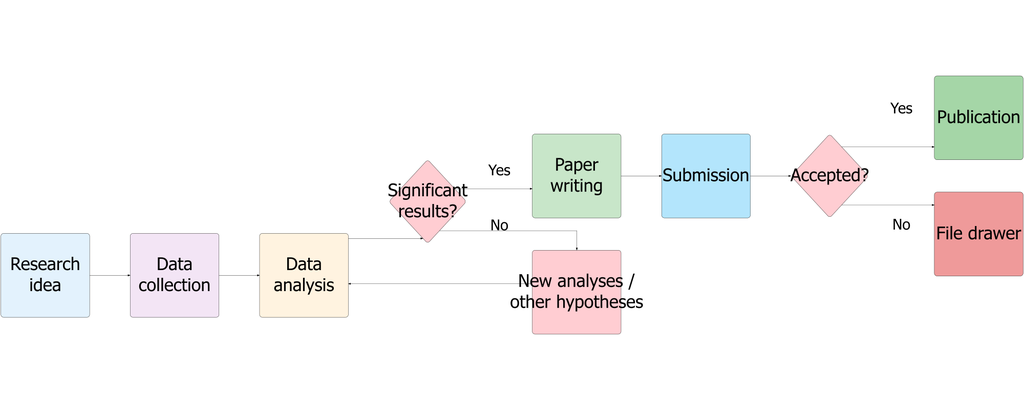

Figure 1: Traditional research workflow

## Workflow with Preregistration

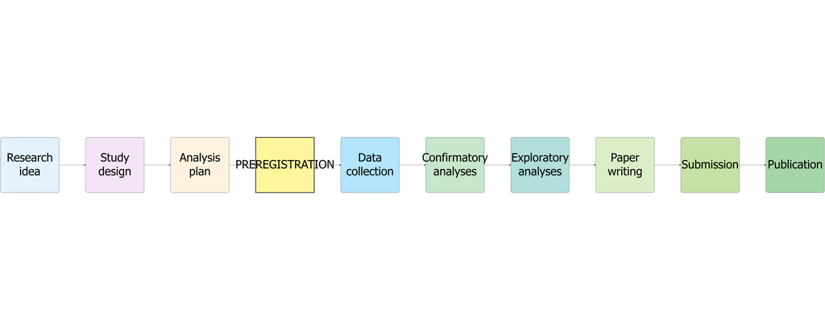

Figure 2: Research workflow with preregistration

## Paradigm shift: the research workflow

- Focus on statistically significant results
- Publication depends on results
- Pressure toward “positive” findings
- P-value < 0.05 as a publication criterion
- Hidden analytical flexibility

## Preregistered paradigm

- Focus on methodological quality and transparency
- Publication depends on methodological rigor
- Value of null results and confirmations
- Pre-specified analysis plan
- Deviations declared and justified
- All registered studies are traceable

**“Preregistration distinguishes analyses that result from predictions from those that result from postdictions”** Nosek et al., 2018

## Many Templates

| Template | Descrizione | Link |
| --- | --- | --- |
| **OSF Preregistration** | Standard and general template for empirical studies | OSF.IO/VH8PB |
| **Open-Ended Registration** | Flexible, for complex projects | OSF.IO/YRP3F |
| **AsPredicted** | Short and structured (from aspredicted.org) | [aspredicted.org](https://aspredicted.org/) |
| **Generalized Systematic Review** | For systematic reviews and meta-analyses | OSF.IO/F8QD5 |
| **OSF-Standard Pre-Data Collection** | Confirms that data have not yet been collected | OSF.IO/VH8PB |
| **Qualitative Preregistration** | For primarily qualitative studies | OSF.IO/SWJMN |
| **Registered Report Protocol** | After in-principle acceptance | OSF.IO/P5SJB |

## Materials and Resources

## Where to Find Templates and Guides

**Methodological Review Board**

- **OSF Registries**: [osf.io/registries](https://osf.io/registries/)
- **AsPredicted**: [aspredicted.org](https://aspredicted.org/)
- **COS Resources**: cos.io/initiatives/prereg

## Other Useful Links

🔗 methodological-review-board.github.io/materials.html

### What You Will Find

- Discipline-specific templates
- Video tutorials
- Examples of preregistrations
- Step-by-step guidelines
- FAQs and troubleshooting
- Best practices

## Critiques and Advantages of Preregistration

## Arguments in Favor

- **Prevents p-hacking** and selective analyses<sup>1</sup><sup>2</sup>
- **Increases transparency** and accountability<sup>3</sup><sup>4</sup>
- **Improves reproducibility** of studies<sup>5</sup><sup>6</sup>
[^1]: [Benefits of Pre-Registration - iCare Handbook](https://books.icarehb.com/4/icarehb-open-science-handbook/120/benefits-of-pre-registration)
[^2]: [Benefits and Concerns of Registration - OSF Support](https://help.osf.io/article/603-benefits-of-registration)
[^3]: [Benefits and Concerns of Registration - OSF Support](https://help.osf.io/article/603-benefits-of-registration)
[^4]: Preregistration (science) - Wikipedia
[^5]: Preregistration (science) - Wikipedia
[^6]: [Preregistration: Definition, advantages, disadvantages - Tilburg University](https://research.tilburguniversity.edu/en/publications/preregistration-definition-advantages-disadvantages-and-how-it-ca)

## Arguments in Favor

- **Encourages more rigorous design**: requirement to plan in advance<sup>1</sup><sup>2</sup>
- **Reduces publication bias**: null results have a public record<sup>3</sup>
- **Protects against external pressures** (funders, policy makers)<sup>4</sup>
- **Facilitates collaboration**: plans shared and discussed in advance<sup>5</sup><sup>6</sup>
[^7]: [Benefits of Pre-Registration - iCare Handbook](https://books.icarehb.com/4/icarehb-open-science-handbook/120/benefits-of-pre-registration)
[^8]: [Pre-registering your research - Leiden University](https://www.staff.universiteitleiden.nl/news/2025/09/pre-registering-your-research-extra-effort-but-whats-the-pay-off)
[^9]: [The pros and cons of research preregistration - OUP Blog](https://blog.oup.com/2014/09/pro-con-research-preregistration/)
[^10]: [The pros and cons of research preregistration - OUP Blog](https://blog.oup.com/2014/09/pro-con-research-preregistration/)
[^11]: Preregistration (science) - Wikipedia
[^12]: [A survey on how preregistration affects the research workflow](https://pmc.ncbi.nlm.nih.gov/articles/PMC9257590/)

### Main Criticisms

- **Discourages exploratory research**: prioritizes a priori hypotheses only<sup>1</sup><sup>2</sup>
- **Excessive rigidity**: difficult to adapt to unexpected discoveries<sup>3</sup><sup>4</sup>
- **May increase initial workload** and project duration<sup>5</sup>
- **Risk of bureaucratization**: preregistration as a formal “badge” rather than a tool<sup>6</sup>
[^13]: [The pros and cons of pre-registration in fundamental research](https://www.cogsci.nl/blog/miscellaneous/215-the-pros-and-cons-of-pre-registration-in-fundamental-research)
[^14]: [Pre-Registration of Scientific Studies: Pros and Cons - YouTube](https://www.youtube.com/watch?v=sWAINSENvOI)
[^15]: [The pros and cons of research preregistration - OUP Blog](https://blog.oup.com/2014/09/pro-con-research-preregistration/)
[^16]: [The pros and cons of pre-registration in fundamental research](https://www.cogsci.nl/blog/miscellaneous/215-the-pros-and-cons-of-pre-registration-in-fundamental-research)
[^17]: [A survey on how preregistration affects the research workflow - PMC](https://pmc.ncbi.nlm.nih.gov/articles/PMC9257590/)
[^18]: [On the Use and Misuses of Preregistration - PMC](https://pmc.ncbi.nlm.nih.gov/articles/PMC11871985/)

### Main Criticisms

- **Not suitable for all data types** (e.g., secondary data, complex qualitative studies)<sup>1</sup>
- **Conflict with multiverse analyses** if interpreted rigidly<sup>2</sup>
[^19]: [A survey on how preregistration affects the research workflow](https://pmc.ncbi.nlm.nih.gov/articles/PMC9257590/)
[^20]: [On the Use and Misuses of Preregistration - PMC](https://pmc.ncbi.nlm.nih.gov/articles/PMC11871985/)

**Preregistration is a powerful tool but not a universal solution. It is important to distinguish confirmatory research (which benefits greatly) from exploratory research (which requires flexibility).**

## Example (in my experience)

## Real-World Preregistration Examples

### Different Preregistrations in Action

**1. Clinical Psychology Study Preregistration**  
[OSF Preprint: Clinical Psychology Study](https://osf.io/preprints/osf/6krn7_v1)

**2. Multilab Secondary Analysis Preregistration**  
[OSF Project: Secondary Data Analysis](https://osf.io/wt79h/overview)

**3. Multilab Pre-Data Collection Registration**  
[HAL Science](https://hal.science/hal-04383754/) | [ManyBabies MB5 Project](https://manybabies.org/MB5/)

**4. Preregistered Multilab Analysis (Published)**  
[Science Direct: Multilab Study](https://www.sciencedirect.com/science/article/pii/S0163638323000826)

**5. My First Preregistration (2019)**  
[OSF Project: First Attempt](https://osf.io/pefw8/overview)

**These examples show the diversity of preregistration approaches: single-lab clinical studies, secondary data analysis, large collaborative projects (ManyBabies), and published multilab studies. Each demonstrates how preregistration adapts to different research contexts.**